# Angiotensin II Receptor Type 1

**by Yulissa Lopez**

# Introduction

**Scientific Question:**

Is the angiotensin II receptor type 1 of a house mice more genetically expressed than a human, therefore explaining why there needs to be more blood regulation in mice due to their smaller bodies?

**What is Angiotensin II type 1 receptor?**

The angiotensin II receptor type 1 is a part of the renin-angiotensin system. The renin-angiotensin system is a regulator of blood volume and and maintain normal levels/processes for cardiovascular functions. When renin(enzyme) is released into the blood, it targets angiotensin which is then cleaved into angiotensin I. Then angiotensin I is now a inactivated predecessor that can be catalyzed by an enzyme to be convereted into angiotensin II type I receptor.

Mice have very similar functions to their biological and gene components as they have similar organs and systems. According to Jackson Laboratories that almost all the genes that mice have share funstion with genes that are in humans. For example, in our case angiotensin II receptor is also found in mice but with a ditinct modification although humans have only one type one receptor. Mice have two angiotensin II subtype receptors, there is 1a and 1b. They angiotensin II receptor type 1a in mice regulates blood pressure and contributes to many cardiovascular function(Chia_Hua et al. 2008.) Meanwhile angiotensin II receptor type 1b doesn’t have any evidence of contributing to functions of type 1a there is an association between type 1b and vasculature contractility. Vasculature contractility which is the regulation of lumenal diameter of the resistance vessels, which makes it a significant contribution to setting the level of blood pressure and blood flow(Shao-wei et al. 2017.)

*Sources* - https://www.ncbi.nlm.nih.gov/books/NBK470410/

- https://www.ahajournals.org/doi/10.1161/atvbaha.118.311282
- https://www.jax.org/why-the-mouse/excellent-models#:~:text=Humans%20and%20mice%20don’t,lungs%2C%20kidneys%2C%20etc.)
- https://medlineplus.gov/genetics/gene/agtr1/#:~:text=Variations%20in%20the%20AGTR1%20gene,diabetes%20that%20affects%20kidney%20function.
- https://www.nature.com/articles/aps201718#:~:text=Vascular%20contractility%20depends%20on%20vascular,blood%20flow%20to%20vascular%20beds.

**Scientific Hypothesis:**

If the angiotensin receptor II type 1 were to be more genetically expressed in mice that would then explain that mice need more blood regulation than humans due to their higher heart rate and respiratory rate because of their body size.

**Data Analyses**

# What are the Packages for?

**Multiple Sequence Alignment**

Biostrings: it is a package that can manipulate, match, and differentiate biological sequences.

Protor: is a package that can download protein sequences from various representation schemes by putting an ID number of the gene(s), for this code the sequence is being downloaded from UniProt.

MSA: the multiple sequence alignment package is used to store multiple alignment algorithm results.

```r
library(Biostrings)
library(protr)
library(msa)
```

*Source*

- https://www.rdocumentation.org/packages
- https://r-graph-gallery.com/215-the-heatmap-function.html

**Heat Map**

BiocManager: the first if statement up to BiocManager install is a package that that allows one to install, update, and decide what version to download or use for the code.

Biostrings: we use this package for the heatmap as well. It is a package that can manipulate, match, and differentiate biological sequences.

ggmsa: it is a package that gives multiple visual outputs of different sequence alignments.

RColorBrewer: this package is used to add or choose the color of a diffrent graphical outputs. In this case we use it to choose the color of the heatmap.

```r
if (!require("BiocManager", quietly = TRUE))
    install.packages("BiocManager")
BiocManager::install("ggmsa")
library(Biostrings)
library(ggmsa)
library(RColorBrewer)
```

*Source*

- https://r-graph-gallery.com/215-the-heatmap-function.html

**Homology Modeling and Structural Bioinformatics**

NGLVieweR: is a way to view different protein and molecular structures through PDB files.

bio3d.view: gives a 3-D interactive visualization, in our case we use it to look at AGTR.

```r
library(NGLVieweR)
library(bio3d.view)
```

*Source*

- https://bioboot.github.io/bimm143_S19/class-material/lecture11-BIMM143_F18.pdf
- https://nvelden.github.io/NGLVieweR/index.html
- http://thegrantlab.org/bio3d_v2/html/dist.xyz.html
- http://thegrantlab.org/bio3d_v2/html/vignettes/Bio3D_pca.pdf

# Data Analysis

**Data Sets**

The data sets below are looking at the gene angiotensin II receptor from two different species. Below I have listed the reference number and the species correlated with it. As well as the NCBI UniProt IDs.

*Homo sapiens*(human) type 1: NC_000003.12, P30556

*Mus musculus*(house mouse) type 1a: NC_000079.7, P29754

*Mus musculus*(house mouse) type 1b:NC_000069.7, P29755

**Multiple Sequence Alignment**

The purpose of a multiple sequence alignment is to see which genes and proteins are similar between multiple specimen. As well to compare and contrast the species sequence of the gene. First the data is read in from NCBI UniProt using the ID’s.Then once the ID’s are read in from UniProt we use the AAStringSet to store the sequence together as if it was a fasta. Then the msa function is used to compare the sequences between the specimen.

```r
#UniProt genes are being read in to a single vector to have the ID's in one place
IDs <- c("P30556", "P29754", "P29755")
#The ID's are then read into the code from the database by using the getUniProt function.
Proteins_IDs <- getUniProt(IDs)
#The vector is getting renamed from ID's to Proteins_IDs
names(Proteins_IDs) <- IDs
#All of the sequences from the ID are being stored in one place to then be stored through a fasta file, then be able to manipulate the sequence.The 'multifasta' is now considered a global variable as it is used throughout the code in different chunks.
multifasta <- Biostrings::AAStringSet(unlist(Proteins_IDs))
# This allows it to be stored to a fast file.
Biostrings::writeXStringSet(multifasta, "your_multifasta.fa")
# We use the msa to analyze the different sequences.
specimen_MSA <- msa(multifasta)
```

```
## use default substitution matrix
```

```r
#This then prints the complete analysis.
print(specimen_MSA, show="complete")
```

```
##
## MsaAAMultipleAlignment with 3 rows and 359 columns
##     aln (1..54)                                            names
## [1] MILNSSTEDGIKRIQDDCPKAGRHNYIFVMIPTLYSIIFVVGIFGNSLVVIVIY P30556
## [2] MALNSSTEDGIKRIQDDCPRAGRHSYIFVMIPTLYSIIFVVGIFGNSLVVIVIY P29754
## [3] MILNSSIEDGIKRIQDDCPKAGRHNYIFVMIPTLYSIIFVVGIFGNSLVVIVIY P29755
## Con MILNSSTEDGIKRIQDDCPKAGRHNYIFVMIPTLYSIIFVVGIFGNSLVVIVIY Consensus
##
##     aln (55..108)                                          names
## [1] FYMKLKTVASVFLLNLALADLCFLLTLPLWAVYTAMEYRWPFGNYLCKIASASV P30556
## [2] FYMKLKTVASVFLLNLALADLCFLLTLPLWAVYTAMEYRWPFGNHLCKIASASV P29754
## [3] FYMKLKTVASVFLLNLALADLCFLLTLPLWAVYTAMEYQWPFGNHLCKIASASV P29755
## Con FYMKLKTVASVFLLNLALADLCFLLTLPLWAVYTAMEYRWPFGNHLCKIASASV Consensus
##
##     aln (109..162)                                         names
## [1] SFNLYASVFLLTCLSIDRYLAIVHPMKSRLRRTMLVAKVTCIIIWLLAGLASLP P30556
## [2] SFNLYASVFLLTCLSIDRYLAIVHPMKSRLRRTMLVAKVTCIIIWLMAGLASLP P29754
## [3] SFNLYASVFLLTCLSIDRYLAIVHPMKSRLRRTMLVAKVTCIIIWLMAGLASLP P29755
## Con SFNLYASVFLLTCLSIDRYLAIVHPMKSRLRRTMLVAKVTCIIIWLMAGLASLP Consensus
##
##     aln (163..216)                                         names
## [1] AIIHRNVFFIENTNITVCAFHYESQNSTLPIGLGLTKNILGFLFPFLIILTSYT P30556
## [2] AVIHRNVYFIENTNITVCAFHYESRNSTLPIGLGLTKNILGFLFPFLIILTSYT P29754
## [3] AVIHRNVYFIENTNITVCAFHYESQNSTLPIGLGLTKNILGFVFPFVIILTSYT P29755
## Con AVIHRNVYFIENTNITVCAFHYESQNSTLPIGLGLTKNILGFLFPFLIILTSYT Consensus
##
##     aln (217..270)                                         names
## [1] LIWKALKKAYEIQKNKPRNDDIFKIIMAIVLFFFFSWIPHQIFTFLDVLIQLGI P30556
## [2] LIWKALKKAYEIQKNKPRNDDIFRIIMAIVLFFFFSWVPHQIFTFLDVLIQLGV P29754
## [3] LIWKALKKAYKIQKNTPRNDDIFRIIMAIVLFFFFSWVPHQIFSFLDVLIQLGV P29755
## Con LIWKALKKAYEIQKNKPRNDDIFRIIMAIVLFFFFSWVPHQIFTFLDVLIQLGV Consensus
##
##     aln (271..324)                                         names
## [1] IRDCRIADIVDTAMPITICIAYFNNCLNPLFYGFLGKKFKRYFLQLLKYIPPKA P30556
## [2] IHDCKIADIVDTAMPITICIAYFNNCLNPLFYGFLGKKFKKYFLQLLKYIPPKA P29754
## [3] IHDCEIADVVDTAMPITICIAYFNNCLNPLFYGFLGKKFKRYFLQLLKYIPPKA P29755
## Con IHDC?IADIVDTAMPITICIAYFNNCLNPLFYGFLGKKFKRYFLQLLKYIPPKA Consensus
##
##     aln (325..359)                      names
## [1] KSHSNLSTKMSTLSYRPSDNVSSSTKKPAPCFEVE P30556
## [2] KSHSSLSTKMSTLSYRPSDNMSSAAKKPASCSEVE P29754
## [3] RSHAGLSTKMSTLSYRPSDNMSSSARKSAYCFEVE P29755
## Con KSHS?LSTKMSTLSYRPSDNMSSSAKKPA?CFEVE Consensus
```

**Heat Map**

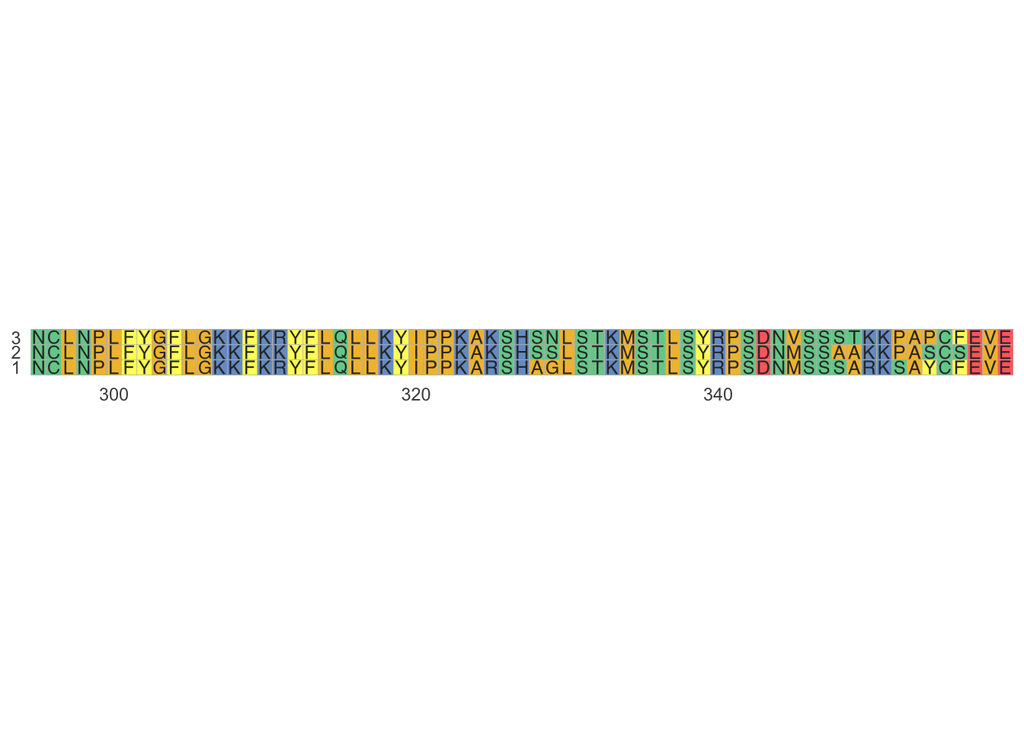

```r
#This function is used to retrieve the piece of sequence that is going to be analyzed from the file.
ggmsa(multifasta, start = 295, end = 360)
```